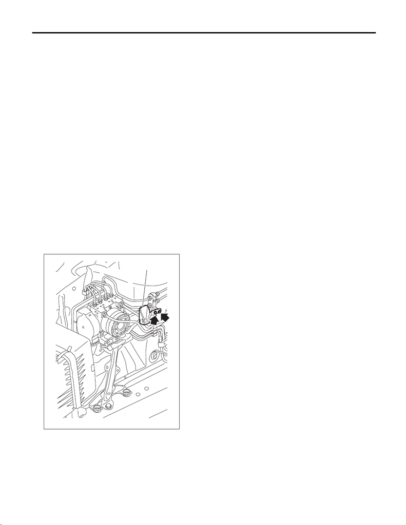

VDC-8

VDC Control Module and Hydraulic Control Unit (VDCCM&H/U)

VEHICLE DYNAMICS CONTROL (VDC)

4. VDC Control Module and Hydraulic Control Unit (VDCCM&H/U)

A: REMOVAL

CAUTION:

• Avoid unnecessary removal of parts in order to prevent fluid leakage.

• When the VDCCM&H/U components are removed, be sure to perform the installation according to

the installation procedures. <Ref. to VDC-10, INSTALLATION, VDC Control Module and Hydraulic

Control Unit (VDCCM&H/U).>

1) Disconnect the ground cable from battery. <Ref. to NT-5, BATTERY, NOTE, Note.>

NOTE:

For models other than STI model, disconnect the ground terminal from battery sensor.

2) Remove the engine control module (ECM). (Except for STI model) <Ref. to FU(w/o STI)-132, REMOVAL,

Engine Control Module (ECM).>

3) Remove the chamber assembly. (STI model) <Ref. to IN(STI)-22, REMOVAL, Chamber Assembly.>

4) Remove the VDC control module & hydraulic control unit (VDCCM&H/U).

CAUTION:

• Do not pull on the harness when disconnecting the connector.

• Wrap the brake pipe with a vinyl bag so as not to spill the brake fluid on the painted surface of the

vehicle body.

• If brake fluid is spilled on the painted surface of the vehicle body, wash it off immediately with wa-

ter and wipe clean.

(1) Remove any dirt from around the VDCCM&H/U.

(2) Remove the power steering control module. (Except for STI model) <Ref. to PS-84, REMOVAL, Pow-

er Steering Control Module.>

(3) Remove the nuts, and remove the bracket (a) from the bracket - connector front. (Except for STI model)

VDC01290

(a)

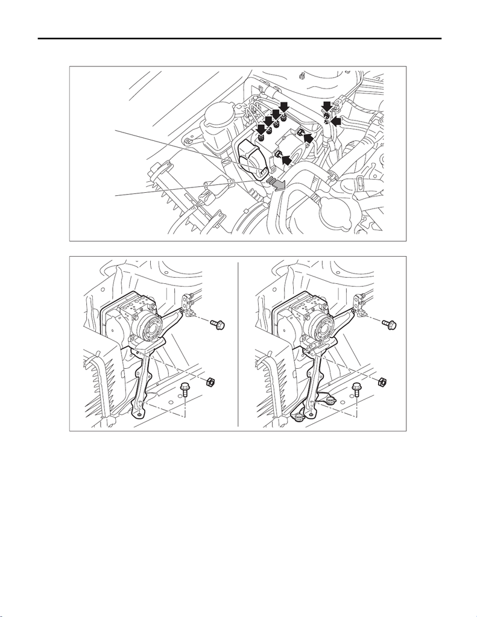

VDC-9

VDC Control Module and Hydraulic Control Unit (VDCCM&H/U)

VEHICLE DYNAMICS CONTROL (VDC)

(4) Pull up the lock lever (b) while pressing the lock button (a) and disconnect the VDCCM&H/U connector.

(5) Separate each brake pipe using a flare nut wrench.

(6) Remove the bolts and nuts, and remove the bracket - hydraulic unit and the VDCCM&H/U.

(A) STI model (B) Except for STI model

(a)

(b)

VDC01268

(A) (B)

VDC01316

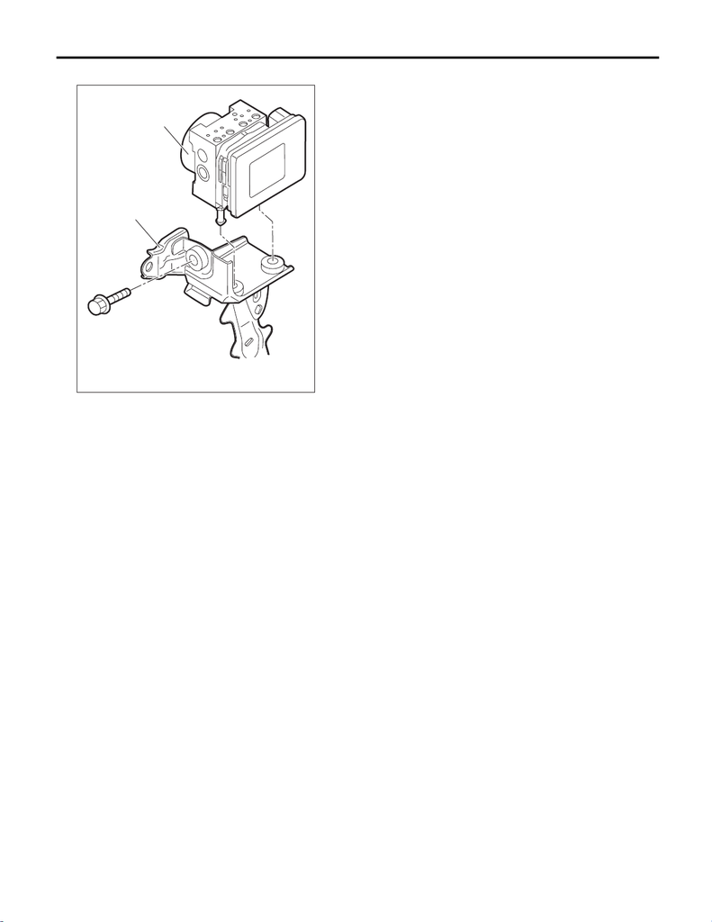

VDC-10

VDC Control Module and Hydraulic Control Unit (VDCCM&H/U)

VEHICLE DYNAMICS CONTROL (VDC)

(7) Remove the bolts, and remove the VDCCM&H/U (a) from the bracket - hydraulic unit (b).

B: INSTALLATION

CAUTION:

• When installing the VDCCM&H/U to the bracket - hydraulic unit, make sure that there is no oil ad-

hered to the bolts and the threads of VDCCM&H/U. If the oil is adhered, degrease it carefully before

tightening.

• Connect the VDCCM&H/U connector securely.

1) Install the bracket - hydraulic unit and the VDCCM&H/U.

(1) Install the VDCCM&H/U to the bracket - hydraulic unit.

Tightening torque:

7.5 N·m (0.8 kgf-m, 5.5 ft-lb)

(2) Attach the bracket - hydraulic unit.

Tightening torque:

33 N·m (3.4 kgf-m, 23.8 ft-lb)

(3) Attach the bracket to the bracket - connector front. (Except for STI model)

Tightening torque:

7.5 N·m (0.8 kgf-m, 5.5 ft-lb)

(4) Install the power steering control module. (Except for STI model) <Ref. to PS-84, INSTALLATION,

Power Steering Control Module.>

(5) Connect the VDCCM&H/U connector.

(6) Install each brake pipe using a flare nut wrench.

Tightening torque:

Refer to “COMPONENT” of “General Description”. <Ref. to VDC-4, VDC CONTROL MODULE & HY-

DRAULIC CONTROL UNIT (VDCCM&H/U), COMPONENT, General Description.>

VDC01291

(b)

(a)

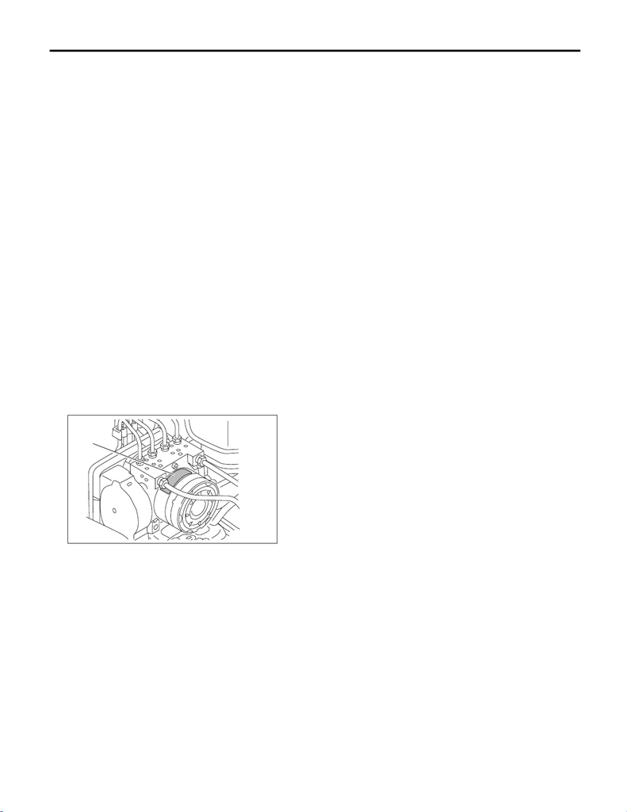

VDC-11

VDC Control Module and Hydraulic Control Unit (VDCCM&H/U)

VEHICLE DYNAMICS CONTROL (VDC)

2) Install the chamber assembly. (STI model) <Ref. to IN(STI)-22, INSTALLATION, Chamber Assembly.>

3) Install the engine control module (ECM). (Except for STI model) <Ref. to FU(w/o STI)-134, INSTALLA-

TION, Engine Control Module (ECM).>

4) Connect the battery ground terminal. <Ref. to NT-5, BATTERY, NOTE, Note.>

NOTE:

For models other than STI model, connect the ground terminal to battery sensor.

5) Bleed air from the brake system. <Ref. to BR-65, Air Bleeding.>

6) Perform parameter confirmation, selection, and registration.

NOTE:

• When the VDCCM&H/U is replaced with a new part, be sure to perform the selection · registration opera-

tion.

• Be sure to use the Subaru Select Monitor for the selection and registration of parameter.

• When the registration has not been performed, the DTC code “Parameter selection error” is detected to-

gether with the ABS/EBD/VDC warning light illumination.

(1) Check that the applied model and grade of the relevant vehicle are included. <Ref. to VDC(diag)-18,

READ PARAMETER, OPERATION, Subaru Select Monitor.>

(2) On {Confirm on parameter} display, enter the applied model of the relevant vehicle and check if it is

correct. If the information is not correct, perform parameter selection and registration. <Ref. to VDC(di-

ag)-17, PARAMETER SELECTION, OPERATION, Subaru Select Monitor.>

7) Perform “VDC sensor midpoint setting mode”. <Ref. to VDC-16, VDC SENSOR MIDPOINT SETTING

MODE, ADJUSTMENT, VDC Control Module and Hydraulic Control Unit (VDCCM&H/U).>

C: INSPECTION

1) Check the identification (a) of the VDC control module & hydraulic control unit (VDCCM&H/U).

NOTE:

For the identification, refer to “SPECIFICATION” in “General Description”. <Ref. to VDC-2, SPECIFICATION,

General Description.>

2) Check the condition of connection and settlement of connector, and correct or replace if defective.

(a)

VDC01289

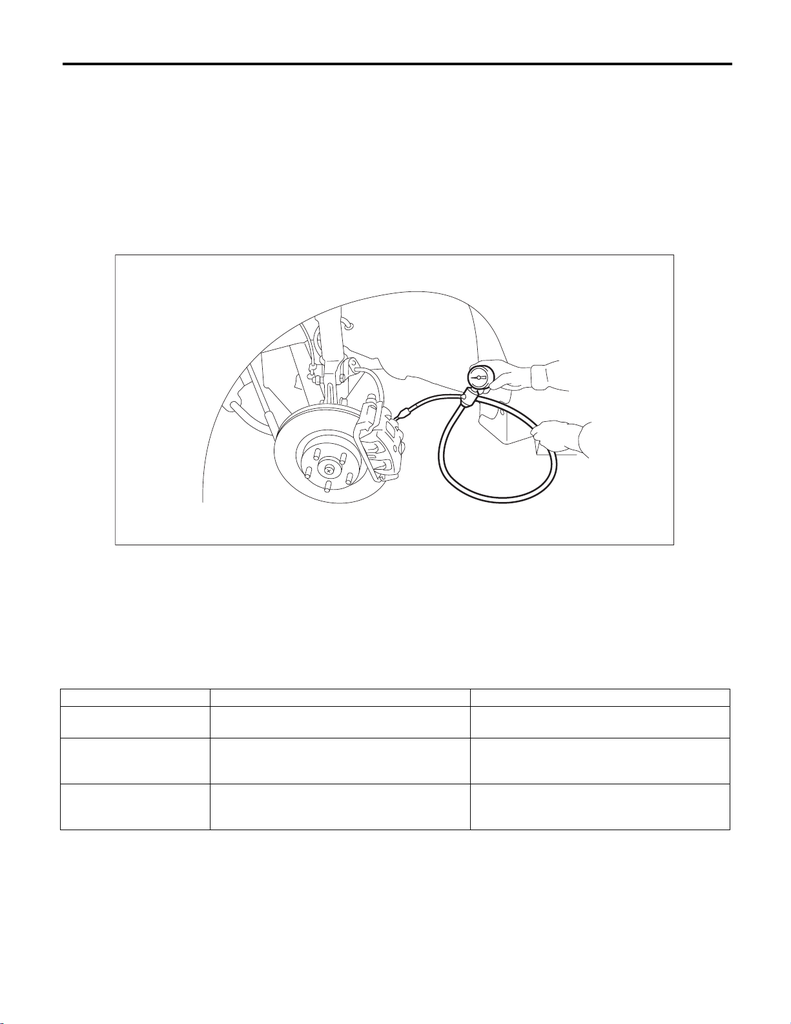

VDC-12

VDC Control Module and Hydraulic Control Unit (VDCCM&H/U)

VEHICLE DYNAMICS CONTROL (VDC)

1. CHECKING THE HYDRAULIC UNIT ABS OPERATION BY PRESSURE GAUGE

1) Lift up the vehicle, and then remove the wheel.

2) Remove the bleeder - screws from the front LH and front RH caliper bodies.

3) Connect two pressure gauges to front LH and front RH caliper bodies.

CAUTION:

• Use a pressure gauge used exclusively for brake fluid measurement.

• Do not use the pressure gauge used for the measurement of transmission oil. Doing so will cause

the piston seal to expand and deform.

NOTE:

Wrap sealing tape around the pressure gauge.

4) Bleed air from the pressure gauges and the front LH and front RH caliper bodies.

5) Perform ABS sequence control. <Ref. to VDC-17, ABS Sequence Control.>

NOTE:

When the hydraulic unit begins to work, first the front LH side performs decompression, hold and compres-

sion, and then the front RH side performs decompression, hold and compression.

6) Read values indicated on the pressure gauge and check if the fluctuation of the values between decom-

pression and compression meets the standard values. Depress the brake pedal and check that the kick-back

is normal, and tightness is normal.

Inspection conditions Front wheel Rear wheel

Initial value

3,500 kPa

(36 kgf/cm

2

, 511 psi)

3,500 kPa

(36 kgf/cm

2

, 511 psi)

When depressurized

500 kPa

(5 kgf/cm

2

, 73 psi)

or less

500 kPa

(5 kgf/cm

2

, 73 psi)

or less

When pressurized

3,500 kPa

(36 kgf/cm

2

, 511 psi)

or more

3,500 kPa

(36 kgf/cm

2

, 511 psi)

or more

VDC00937

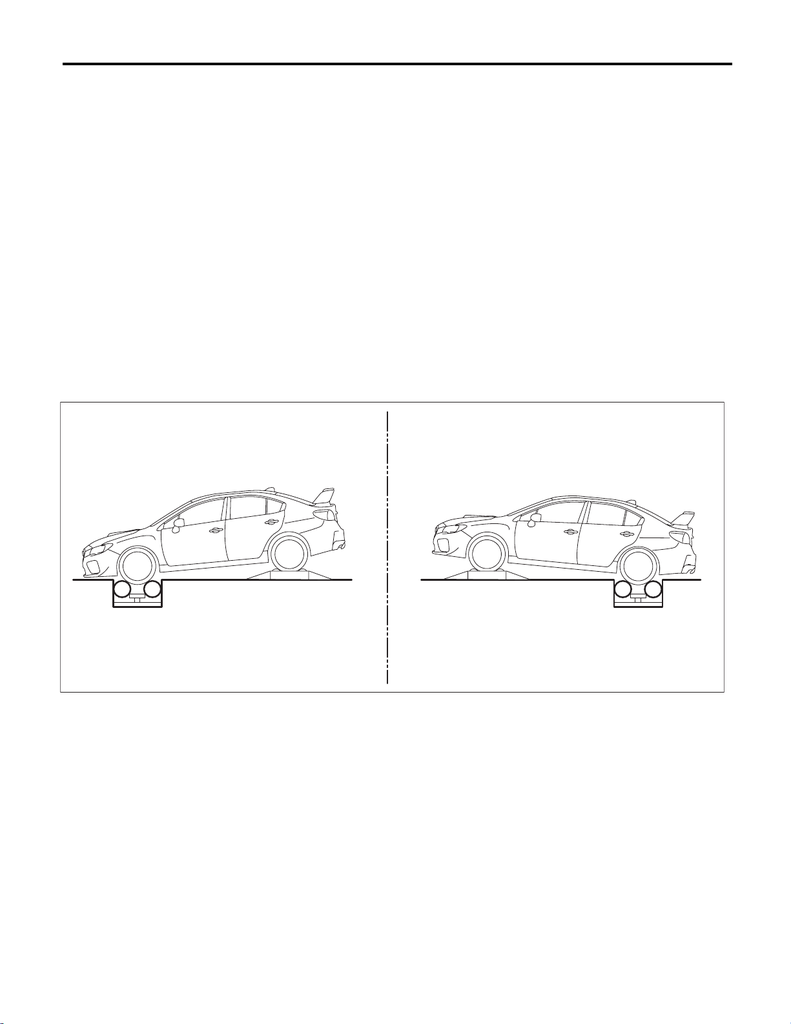

VDC-13

VDC Control Module and Hydraulic Control Unit (VDCCM&H/U)

VEHICLE DYNAMICS CONTROL (VDC)

7) Remove the pressure gauge from the front LH and front RH caliper bodies.

8) Install the bleeder - screws of the front LH and front RH caliper bodies.

9) Remove the bleeder - screws from the rear LH and rear RH caliper bodies.

10) Connect two pressure gauges to rear LH and rear RH caliper bodies.

11) Bleed air from the pressure gauges and the rear LH and rear RH caliper bodies.

12) Perform ABS sequence control. <Ref. to VDC-17, ABS Sequence Control.>

NOTE:

13) Read values indicated on the pressure gauge and check if the fluctuation of the values between decom-

pression and compression meets specification. Depress the brake pedal and check that the kick-back is nor-

mal, and tightness is normal.

14) Remove the pressure gauge from the rear LH and rear RH caliper bodies.

15) Install the bleeder - screws of the rear LH and rear RH caliper bodies.

16) Bleed air from the brake system. <Ref. to BR-65, Air Bleeding.>

2. CHECKING THE HYDRAULIC UNIT ABS OPERATION WITH THE BRAKE TESTER

1) Set wheels other than the one to measure on free rollers.

2) Prepare for the ABS sequence control operation. <Ref. to VDC-17, ABS Sequence Control.>

3) Set the front wheels or rear wheels on the brake tester (a) and set the gear to neutral.

4) Operate the brake tester.

NOTE:

When any wheel speed reaches 4 km/h (2 MPH), the ABS sequence control stops and ABS operation is re-

turned to the normal control mode.

5) Perform ABS sequence control. <Ref. to VDC-17, ABS Sequence Control.>

6) When the hydraulic unit begins to work, check the following work sequence.

(1) The front LH wheel performs decompression, hold and compression in sequence, and subsequently

the front RH wheel repeats the same cycle.

(2) The rear RH wheel performs decompression, hold and compression in sequence, and subsequently

the rear LH wheel repeats the same cycle.

(a)

(a)

VDC01287

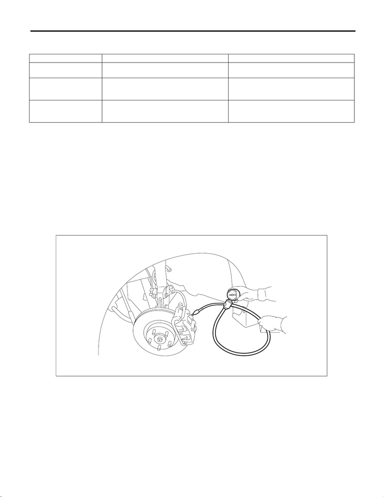

VDC-14

VDC Control Module and Hydraulic Control Unit (VDCCM&H/U)

VEHICLE DYNAMICS CONTROL (VDC)

7) Read values indicated on the brake tester and check if the fluctuation of the values between decompres-

sion and compression meets specification.

8) After the inspection, depress the brake pedal and check that it is not abnormally hard, and tightness is nor-

mal.

3. CHECKING THE HYDRAULIC UNIT VDC OPERATION USING A PRESSURE GAUGE

1) Lift up the vehicle, and then remove the wheel.

2) Remove the bleeder - screws from the front LH and front RH caliper bodies.

3) Connect two pressure gauges to front LH and front RH caliper bodies.

CAUTION:

• Use a pressure gauge used exclusively for brake fluid measurement.

• Do not use a pressure gauge used for the measuring transmission oil pressure, as the piston seal

may expand and deform.

NOTE:

Wrap sealing tape around the pressure gauge.

4) Bleed air from the pressure gauge.

5) Perform VDC sequence control. <Ref. to VDC-20, VDC Sequence Control.>

NOTE:

When the hydraulic unit begins to work, first the front LH side performs compression, hold and decompres-

sion, and then the front RH side performs compression, hold and decompression.

Initial value

1,000 N

(102 kgf, 225 lb)

1,000 N

(102 kgf, 225 lb)

When depressurized

500 N

(51 kgf, 112 lb)

or less

500 N

(51 kgf, 112 lb)

or less

When pressurized

1,000 N

(102 kgf, 225 lb)

or more

1,000 N

(102 kgf, 225 lb)

or more

VDC00937

[figure not shown]

VDC-15

VDC Control Module and Hydraulic Control Unit (VDCCM&H/U)

VEHICLE DYNAMICS CONTROL (VDC)

6) Read values indicated on the pressure gauge and check if the fluctuation of the values between decom-

pression and compression meets specification. Depress the brake pedal and check that it is not abnormally

hard, and tightness is normal.

7) Remove the pressure gauge from the front LH and front RH caliper bodies.

8) Install the bleeder - screws of the front LH and front RH caliper bodies.

9) Remove the bleeder - screws from the rear LH and rear RH caliper bodies.

10) Connect two pressure gauges to rear LH and rear RH caliper bodies.

11) Bleed air from the pressure gauges and the rear LH and rear RH caliper bodies.

12) Perform VDC sequence control. <Ref. to VDC-20, VDC Sequence Control.>

NOTE:

When the hydraulic unit begins to work, first the rear RH side performs compression, hold and decompres-

sion, and then the rear LH side performs compression, hold and decompression.

13) Read the values indicated on the pressure gauges and check if it is within specification. Depress the

brake pedal and check that it is not abnormally hard, and tightness is normal.

14) Remove the pressure gauge from the rear LH and rear RH caliper bodies.

15) Install the bleeder - screws of the rear LH and rear RH caliper bodies.

16) Bleed air from the brake system. <Ref. to BR-65, Air Bleeding.>

4. CHECK HYDRAULIC UNIT VDC OPERATION WITH BRAKE TESTER

1) Set wheels other than the one to measure on free rollers.

2) Prepare to operate the VDC sequence control. <Ref. to VDC-20, VDC Sequence Control.>

3) Set the front wheels or rear wheels on the brake tester (a) and set the gear to neutral.

When pressurized

3,000 kPa

(31 kgf/cm

2

, 441 psi)

or more

3,000 kPa

(31 kgf/cm

2

, 441 psi)

or more

When depressurized

500 kPa

(5 kgf/cm

2

, 73 psi)

or less

500 kPa

(5 kgf/cm

2

, 73 psi)

or less

(a)

(a)

VDC01287

[figure not shown]

VDC-16

VDC Control Module and Hydraulic Control Unit (VDCCM&H/U)

VEHICLE DYNAMICS CONTROL (VDC)

4) Operate the brake tester.

NOTE:

When any wheel speed reaches 4 km/h (2 MPH), the VDC sequence control stops and VDC operation is re-

turned to the normal control mode.

5) Perform VDC sequence control. <Ref. to VDC-20, VDC Sequence Control.>

6) When the hydraulic unit begins to work, check the following work sequence.

(1) The front LH wheel performs compression, hold and decompression in sequence, and subsequently

the front RH wheel repeats the same cycle.

(2) The rear RH wheel performs compression, hold and decompression in sequence, and subsequently

the rear LH wheel repeats the same cycle.

7) Read values indicated on the brake tester and check if the fluctuation of the values between decompres-

sion and compression meets specification.

8) After the inspection, depress the brake pedal and check that it is not abnormally hard, and tightness is nor-

mal.

D: ADJUSTMENT

1. VDC SENSOR MIDPOINT SETTING MODE

After installing, replacing or adjusting the following parts, perform the VDC sensor midpoint setting mode.

• Steering angle sensor

• Steering wheel

• Suspension parts

• Wheel alignment

• VDCCM&H/U

• VDCCM&H/U bracket

1) Park the vehicle on a level surface, and set the steering wheel to the neutral position.

2) Connect the Subaru Select Monitor to data link connector.

(1) Run the “PC application for Subaru Select Monitor”.

(2) On «Main Menu» display, select {Each System Check}.

(3) Select {Brake Control System}. When {VDC} is displayed, select the [OK] button.

(4) From {Current Data Display & Save}, select {Steer Angle Sensor Op}, {Longitudinal G Sensor} and

{Lateral G sensor Output}.

3) Check that the steering angle sensor output value is between –10 and 10 deg.

4) Check that output values for the longitudinal G sensor and lateral G sensor are -2 — 2 m/s

2

.

5) From {Work Support}, select {VDC sensor midpoint setting mode}, and perform the setting according to

the procedure displayed on the Subaru Select Monitor Screen.

6) Drive the vehicle for 10 minutes, and check that there is no system malfunction or the warning light illumi-

nation while driving.

7) Make sure that the DTC is not stored.

When pressurized

2,000 N

(204 kgf, 450 lbf)

or more

2,000 N

(204 kgf, 450 lbf)

or more

When depressurized

500 N

(51 kgf, 112 lbf)

or less

500 N

(51 kgf, 112 lbf)

or less